# HAQ article framework

# Main document

## Introduction

- Amenable mortality defined as …
- Thought to be a useful comparative measure of effectiveness and quality of healthcare
- Has been updated using GBD methodology and study data 2015
- International comparisons published [@ref]
- First time publication of English sub-national comparison
- Describes
  - Variation
  - Trends
  - Cross comparison with conventional method
  - Models variation with deprivation scores
  - Models variation with other metrics of local healthcare quality and performance

## Methods

- Calculation of HAQ described elsewhere
- In brief (to flesh out):
  - Identifies causes of death using Nolte and McKee list [@ref]
  - Recodes using ‘garbage code’ methodology
  - Risk adjusts
  - Calculates PCA
  - Constructs index using first 3 componenets
  - Scales index to 0-100
  - Compares index for each country against SDI using frontier analysis
  - Estimates additional gain/loss in index given countries level of socio-economic deprivation
- Obtain pre-calculated HAQ values for each UTLA from GBD
- Calculate summary metrics (tabulate)
- Plot variation and trends per LA via line charts and maps
- Obtain other metrics of healthcare performance and quality ? what
  - ONS area amenable and avoidable mortality rates (model/ correlation)
  - ?? Healthcare spend - ?is this available by LA - ? or estimation from CCGs
  - ?? SHMI - at provider level but map to LA?
  - Other??
- Simple regression model vs UTLA deprivation score and calculate predicted HAQ

## Results

- Tabular summaries
- Maps and charts
- ? Statistical analysis on trends
- Comparison with amenable mortality from ONS
- Context of other metrics
- Model vs deprivation (IMD)
- Estimates of potential improvement

## Discussion

- Novel method
- Literature about vailidty of amenable mortality as a measure of healthcare performance and quality
- What does this add?
- Paucity of indicators of population healthcare quality
- Potential as a monitoring tool?
- Other ideas?

## Conclusions

# Abstract

## Introduction

## Methods

```
## Your query is GBD[All Fields] AND 2000[PDAT] : 2017[PDAT]. This returns 723 abstracts. By default 1000 abstracts are downloaded. To retrieve more set 'n =' argument to the desired value
```

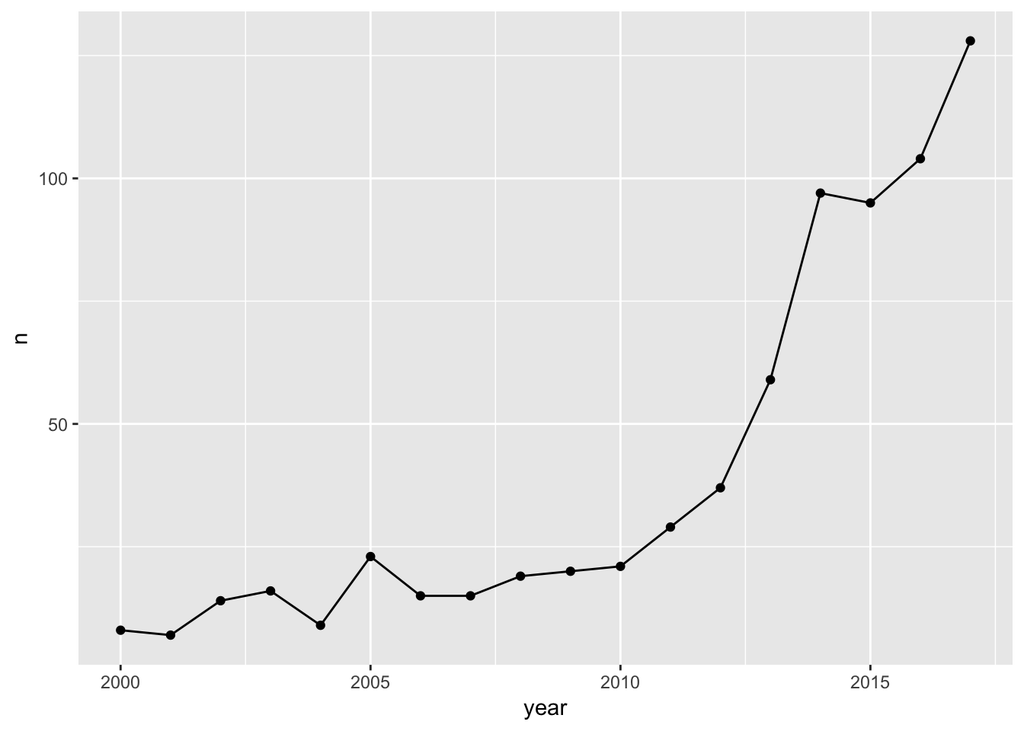

## Results

## Discussion

## Conclusions